# TfL Oyster Card Analysis

Graham Cox

30th May 2022

## A 5% Sample of Oyster Card Journeys on the London Transport Network during 1 week in November 2009.

### Introduction

In this notebook I will analyse a dataset that contains information from TFL Oyster Card journeys. The Oyster card is a contactless payment method and was first introduced in London in June 2003. The card can contain pre-paid tickets for a period of time, travel permits and pre-paid credit for travel, commonly known as Pay-As-You-Go, or PAYG.

The card allows for several on the variety of transport modes available to passengers

- London Underground
- London Buses
- Nation Rail Overground Network
- Docklands Light Railway
- London Tramlink

The Oyster card can also be used on the Emirates Skyline cable car and on certain river boat services. **Data for journeys on these transport modes is not included in this dataset.**

### Questions

1. Does the definition of “rush hour” of the majority of journeys being made between 08:00 and 09:00 and 17:00 and 18:00 hold true with this dataset?
2. What are the busiest locations?
3. What are the top 5 busiest locations within each London Underground Zones 1-9?
4. What are the busiest times of day for each type of Oyster Card?
5. What is the average amount spent for journeys during the rush hour?

### Load Data and Initial Wrangling

```r
# Initial load of data

df <- read_csv("../data/Nov09JnyExport.csv",
               show_col_types = FALSE)

# View dataset

glimpse(df)
```

```
## Rows: 2,623,487
## Columns: 16
## $ downo        <dbl> 3, 4, 3, 4, 6, 6, 5, 5, 5, 2, 7, 3, 3, 3, 4, 7, 5, 5, 4, ~
## $ daytype      <chr> "Tue", "Wed", "Tue", "Wed", "Fri", "Fri", "Thu", "Thu", "~
## $ SubSystem    <chr> "LUL", "LUL", "NR", "NR", "NR", "LUL", "NR", "NR", "LUL",~
## $ StartStn     <chr> "Unstarted", "Unstarted", "Unstarted", "Unstarted", "Unst~
## $ EndStation   <chr> "Kings Cross M", "Sudbury Hill", "Richmond", "Romford", "~
## $ EntTime      <dbl> 0, 0, 0, 0, 0, 0, 0, 0, 0, 0, 0, 0, 0, 0, 0, 0, 0, 0, 0, ~
## $ EntTimeHHMM  <time> 00:00:00, 00:00:00, 00:00:00, 00:00:00, 00:00:00, 00:00:~
## $ ExTime       <dbl> 633, 447, 966, 657, 450, 439, 454, 955, 431, 498, 868, 46~
## $ EXTimeHHMM   <time> 10:33:00, 07:27:00, 16:06:00, 10:57:00, 07:30:00, 07:19:~
## $ ZVPPT        <chr> "Z0104", "Z0110", "Z0304", "Z0110", "Z0104", "Z0104", "Z0~
## $ JNYTYP       <chr> "TKT", "TKT", "TKT", "TKT", "TKT", "TKT", "TKT", "TKT", "~
## $ DailyCapping <chr> "N", "N", "N", "N", "N", "N", "N", "N", "N", "N", "N", "N~
## $ FFare        <dbl> 0, 0, 0, 0, 0, 0, 0, 0, 0, 0, 0, 0, 0, 0, 0, 0, 0, 0, 400~
## $ DFare        <dbl> 0, 0, 0, 0, 0, 0, 0, 0, 0, 0, 0, 0, 0, 0, 0, 0, 0, 0, 400~
## $ RouteID      <chr> "XX", "XX", "XX", "XX", "XX", "XX", "XX", "XX", "XX", "XX~
## $ FinalProduct <chr> "LUL Travelcard-7 Day", "Freedom Pass (Elderly)", "LUL Tr~
```

Let’s clean up the variable names using the `janitor` package.

```r
df <- df %>%
  janitor::clean_names()

glimpse(df)
```

```
## Rows: 2,623,487
## Columns: 16
## $ downo         <dbl> 3, 4, 3, 4, 6, 6, 5, 5, 5, 2, 7, 3, 3, 3, 4, 7, 5, 5, 4,~
## $ daytype       <chr> "Tue", "Wed", "Tue", "Wed", "Fri", "Fri", "Thu", "Thu", ~
## $ sub_system    <chr> "LUL", "LUL", "NR", "NR", "NR", "LUL", "NR", "NR", "LUL"~
## $ start_stn     <chr> "Unstarted", "Unstarted", "Unstarted", "Unstarted", "Uns~
## $ end_station   <chr> "Kings Cross M", "Sudbury Hill", "Richmond", "Romford", ~
## $ ent_time      <dbl> 0, 0, 0, 0, 0, 0, 0, 0, 0, 0, 0, 0, 0, 0, 0, 0, 0, 0, 0,~
## $ ent_time_hhmm <time> 00:00:00, 00:00:00, 00:00:00, 00:00:00, 00:00:00, 00:00~
## $ ex_time       <dbl> 633, 447, 966, 657, 450, 439, 454, 955, 431, 498, 868, 4~
## $ ex_time_hhmm  <time> 10:33:00, 07:27:00, 16:06:00, 10:57:00, 07:30:00, 07:19~
## $ zvppt         <chr> "Z0104", "Z0110", "Z0304", "Z0110", "Z0104", "Z0104", "Z~
## $ jnytyp        <chr> "TKT", "TKT", "TKT", "TKT", "TKT", "TKT", "TKT", "TKT", ~
## $ daily_capping <chr> "N", "N", "N", "N", "N", "N", "N", "N", "N", "N", "N", "~
## $ f_fare        <dbl> 0, 0, 0, 0, 0, 0, 0, 0, 0, 0, 0, 0, 0, 0, 0, 0, 0, 0, 40~
## $ d_fare        <dbl> 0, 0, 0, 0, 0, 0, 0, 0, 0, 0, 0, 0, 0, 0, 0, 0, 0, 0, 40~
## $ route_id      <chr> "XX", "XX", "XX", "XX", "XX", "XX", "XX", "XX", "XX", "X~
## $ final_product <chr> "LUL Travelcard-7 Day", "Freedom Pass (Elderly)", "LUL T~
```

#### Variable Review

Reviewing the variables available in the dataset, the following assumptions are made

- Where `start_stn` equals “Unstarted” or `end_station` equals “Unfinished” these are journeys where the passenger failed to tap-in or tap-out with an Oyster Card at the start or end of their journeys. These observations also have a value of 00:00:00 in either the `ent_time_hhmm` or `ex_time_hhmm` variables. **These observations will be removed**
- The `ZVPPT` variable does not contain meaningful information. **This variable will be removed**
- The `ent_time` and `ex_time` variables do not hold meaningful information. **These variables will be removed**

```r
df <- df %>%
  select(-c(ent_time, ex_time, zvppt)) %>%
  filter(!if_any(start_stn:end_station, ~ .x %in% c("Unstarted", "Unfinished")))
```

#### Review of the `sub_system` variable

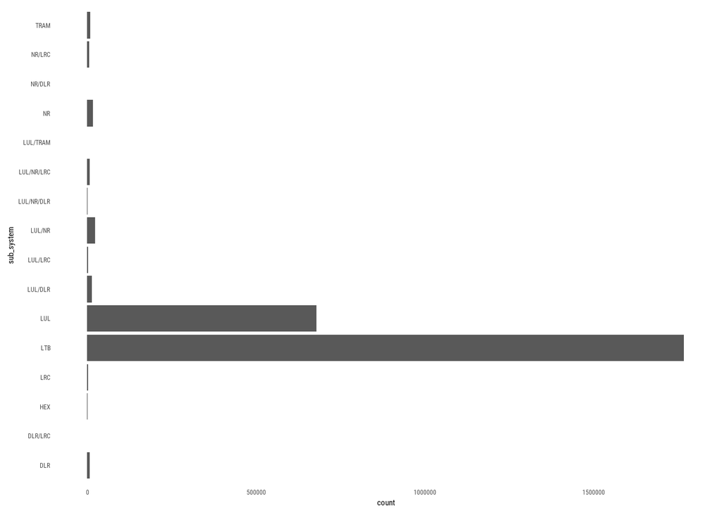

```r
df %>% select(sub_system) %>% group_by(sub_system) %>%
  ggplot(aes(sub_system)) +
  geom_bar() +
  coord_flip()
```

- The highest number of observations are for those journeys on LTB. These observations have a `start_stn` and `end_station` of “BUS”. These observations also have an ex_time_hhmm of “00:00:00”. As passengers are not required to tap-out at the end of the journey, an end time cannot be recorded. **These observations will be removed**
- The remaining `sub_systems` have a considerably lower number of observations compared to the new highest group of “LUL” i.e. London Underground. **All other `sub_system` values will now be removed**
- As the variable named `sub_system` now only contains one value of “LUL”. **This variable can now be removed**
- The variable named `route_id` was for bus journeys only. **This variable can now be removed**

```r
final_df <- df %>%
  filter(sub_system == "LUL") %>%
  select(-c(sub_system, route_id))

glimpse(final_df)
```

```
## Rows: 679,083
## Columns: 11
## $ downo         <dbl> 2, 5, 5, 1, 3, 2, 7, 4, 5, 4, 5, 5, 7, 1, 1, 5, 2, 6, 4,~
## $ daytype       <chr> "Mon", "Thu", "Thu", "Sun", "Tue", "Mon", "Sat", "Wed", ~
## $ start_stn     <chr> "Goodge Street", "Preston Road", "Holborn", "Earls Court~
## $ end_station   <chr> "Totteridge", "Northwood", "Bounds Green", "Pimlico", "B~
## $ ent_time_hhmm <time> 16:40:00, 16:40:00, 16:40:00, 16:40:00, 16:40:00, 16:40~
## $ ex_time_hhmm  <time> 17:21:00, 17:04:00, 17:08:00, 17:01:00, 17:07:00, 17:00~
## $ jnytyp        <chr> "TKT", "TKT", "TKT", "PPY", "TKT", "PPY", "PPY", "PPY", ~
## $ daily_capping <chr> "N", "N", "N", "N", "N", "N", "N", "N", "N", "N", "N", "~
## $ f_fare        <dbl> 0, 0, 0, 160, 0, 110, 160, 220, 0, 0, 0, 160, 0, 220, 0,~
## $ d_fare        <dbl> 0, 0, 0, 160, 0, 110, 160, 220, 0, 0, 0, 160, 0, 220, 0,~
## $ final_product <chr> "Freedom Pass (Elderly)", "Freedom Pass (Disabled)", "LU~
```